# First steps with ggplot2

Group 4: Alex Tai, Momo Mbarek, Zhang Zichen

16/02/2022

We need to load the following packages.

```r
library(ggplot2)
library(tidyverse)
```

### 1. Exercise 1

1. Import the CSV file as a tibble and remove unwanted columns

   ```r
   titanic_1 <- read_csv("titanic.csv", show_col_types = FALSE)

   # remove unwanted columns
   titanic_1 <- titanic_1[, c("class", "survived")]
   ```

2. Make a bar plot of passengers by class

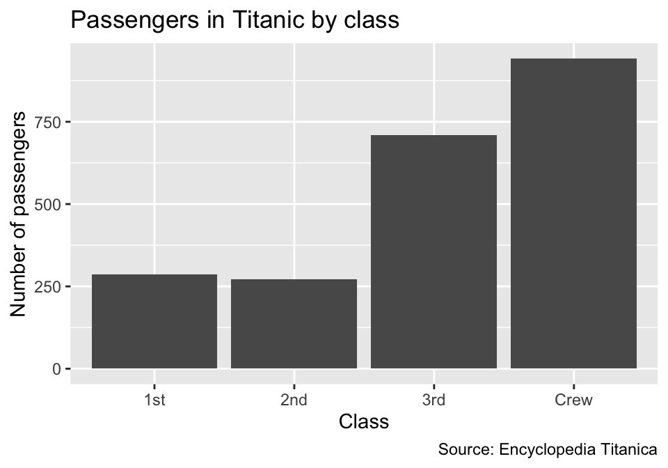

   ```r
     ggplot(titanic_1, aes(x = class)) +
     geom_bar() + labs(
       title = "Passengers in Titanic by class",
       caption = "Source: Encyclopedia Titanica",
       x = "Class",
       y = "Number of passengers"
       )
   ```

3. Make a side-by-side bar plot to visualise the dependence of the number of survivors on their class

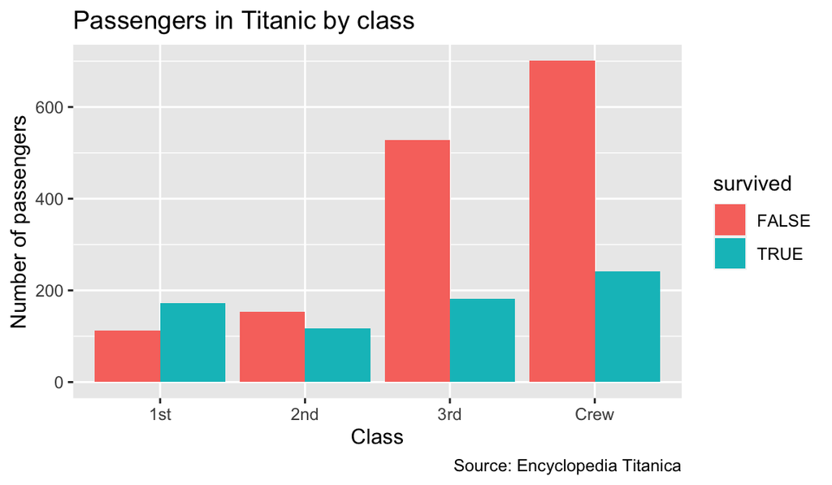

   ```r
     ggplot(titanic_1, aes(fill = survived, x = class)) +
     geom_bar(position = "dodge") + # make the bar plot side-by-side
     labs(
       title = "Passengers in Titanic by class",
       caption = "Source: Encyclopedia Titanica",
       x = "Class",
       y = "Number of passengers"
       )
   ```

4. Turn the built-in data set Titanic into a tibble

   ```r
     titanic_2 <-
     apply(Titanic, c(1, 4), sum) |>
     as_tibble(rownames = "class") |>
     rename(died = "No", survived = "Yes")
   ```

5. Add a column to `titanic_2` with the total number of passengers in each class

   ```r
     titanic_2$total <- titanic_2$died + titanic_2$survived
   ```

   We can see that for `titanic_1`, each passenger is a single data entry which indicates their individual class and survival status. Meanwhile in `titanic_2`, there are no entries for individual passengers, and only the total number of passengers, the number of survived passengers, and the number of passengers who died in each class is included.
6. Redo the plot in (b) with `titanic_2`

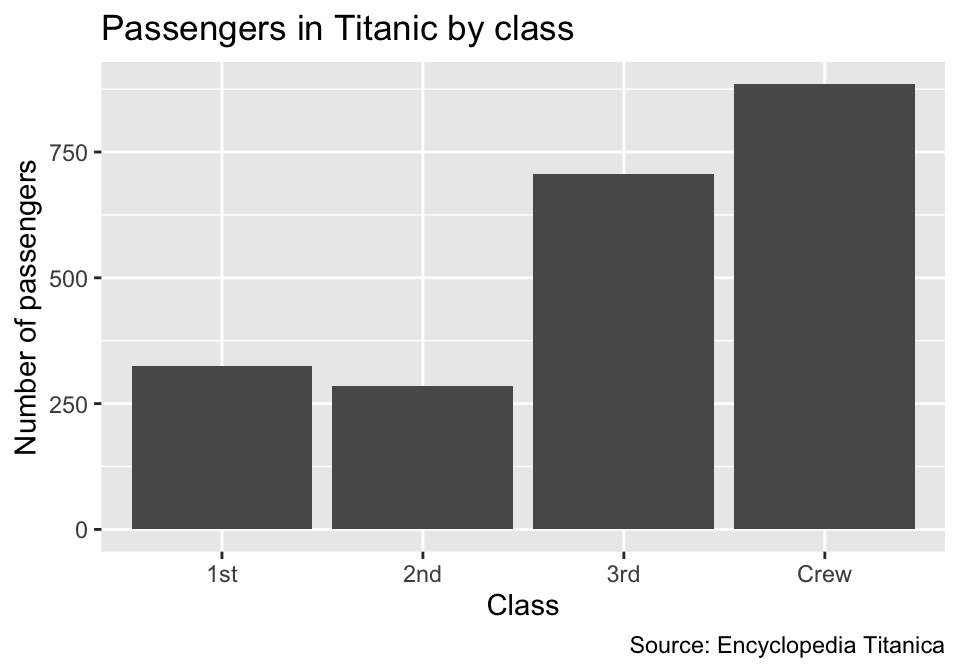

   ```r
     ggplot(titanic_2, aes(x = class, y = total)) +
     geom_bar(stat = "identity") +
     labs(
       title = "Passengers in Titanic by class",
       caption = "Source: Encyclopedia Titanica",
       x = "Class",
       y = "Number of passengers"
       )
   ```

### 2. Exercise 2

1. Change the column Expt to be a factor instead of an integer

   ```r
     # load the data
     data(morley)

     # turn the Expt column into a factor
     morley$Expt <- factor(morley$Expt)
   ```

2. Make a scatter plot of Speed (y-axis) versus experiment number (x-axis)

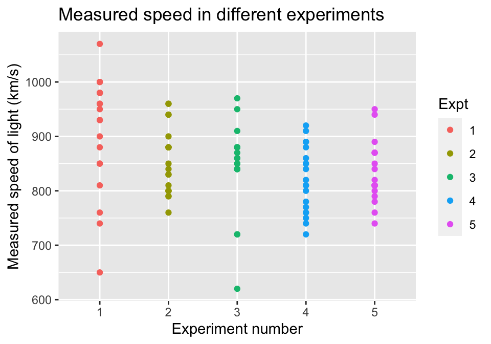

   ```r
     ggplot(morley, aes(x = Expt, y = Speed)) +
     geom_point(
       aes(colour = Expt,
           show.legend = FALSE)) +
     labs(
       title = "Measured speed in different experiments",
       x = "Experiment number",
       y = "Measured speed of light (km/s)")
   ```

3. Make another scatter plot with geom_jitter()

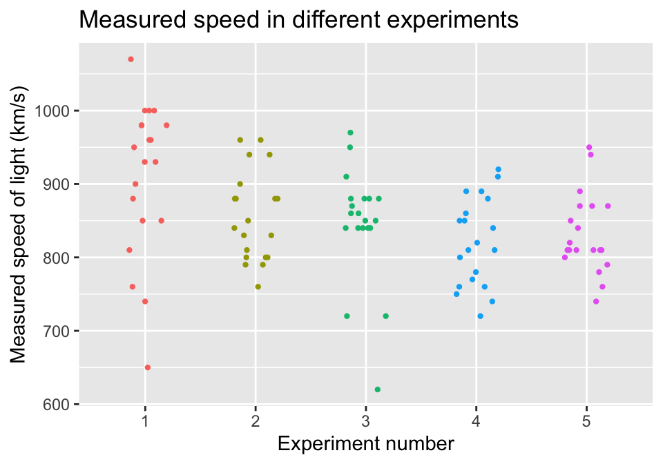

   ```r
     ggplot(morley, aes(Expt, Speed)) +
   geom_jitter(
     width = 0.2,
     height = 0,
     size = 0.8,
     aes(colour = Expt),
     show.legend = FALSE
   ) +
   labs(
     title = "Measured speed in different experiments",
     x = "Experiment number",
     y = "Measured speed of light (km/s)"
   )
   ```

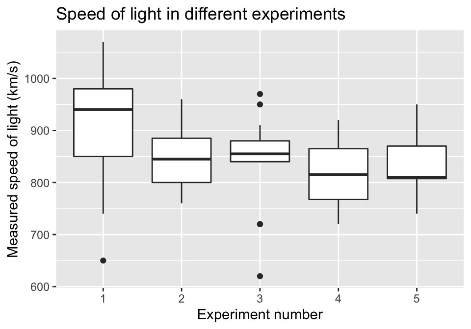

```r
  ggplot(morley, aes(Expt, Speed)) +
  geom_boxplot() +
  labs(
    title = "Speed of light in different experiments",
    x = "Experiment number",
    y = "Measured speed of light (km/s)"
  )
```

6. Make a violin plot with one violin for each experiment number

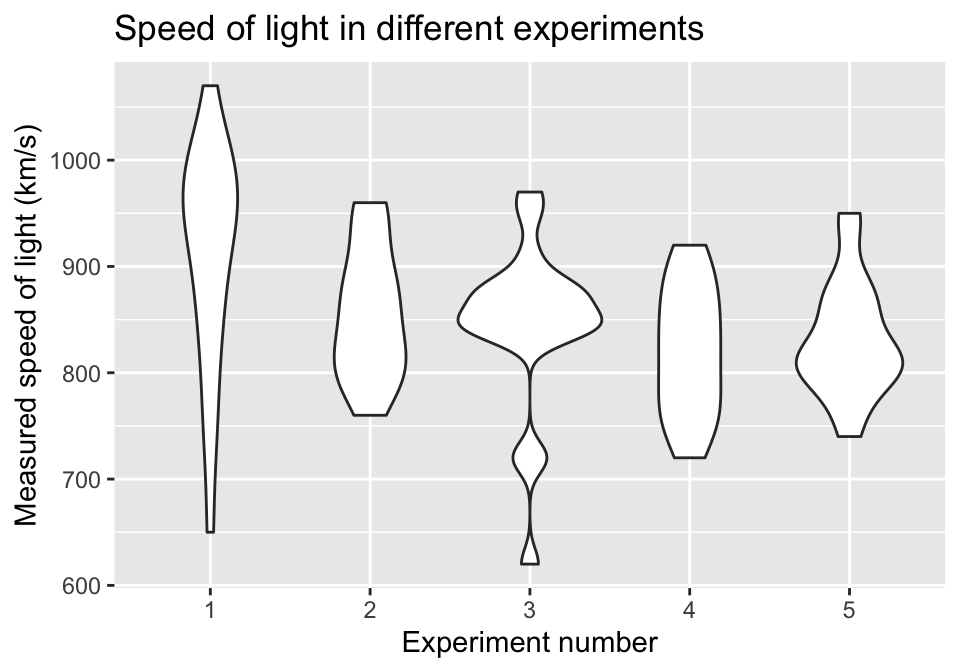

```r
  ggplot(morley, aes(Expt, Speed)) +
  geom_violin() +
  labs(
    title = "Speed of light in different experiments",
    x = "Experiment number",
    y = "Measured speed of light (km/s)"
  )
```

7. What is the advantage of a violin plot compared to a box plot? What is the disadvantage?
- A violin plot is more advantageous than a box plot in showing the probability densities distributed over the entire data range. This is useful when we are interested in the detailed data distribution. If the data is bimodal, for instance, a violin plot woudl allow us to see the different modes while a box plot would not.
- One disadvantage of a violin plot is that it does not show the interquartile range or the median precisely. This would make it harder to compare those characteristics accross different data groups.
8. Make a faceted plot with one histogram for each experiment’s speed distribution

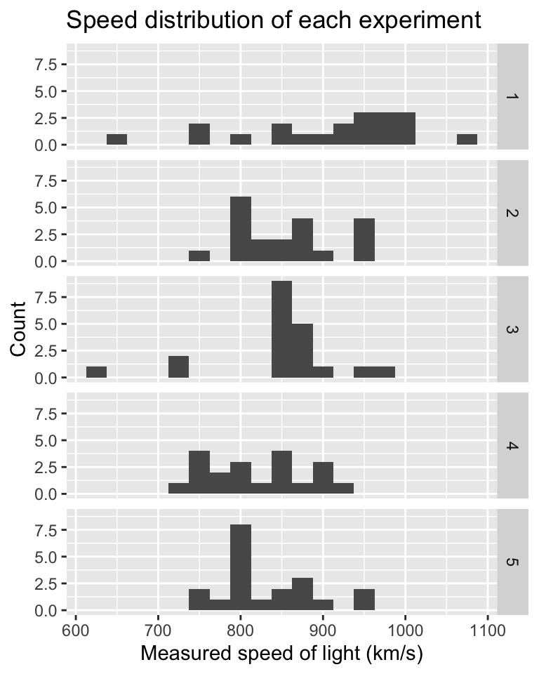

```r
  ggplot(morley, aes(x = Speed)) +
  geom_histogram(binwidth = 25) + # change to a suitable bin width
  facet_grid(Expt ~ .) + # make stacked histograms for each experiment number
  labs(
    title = "Speed distribution of each experiment",
    x = "Measured speed of light (km/s)",
    y = "Count"
  )
```

1. Show the speed distribution of each experiment as a frequency polygon. Do not use faceting.

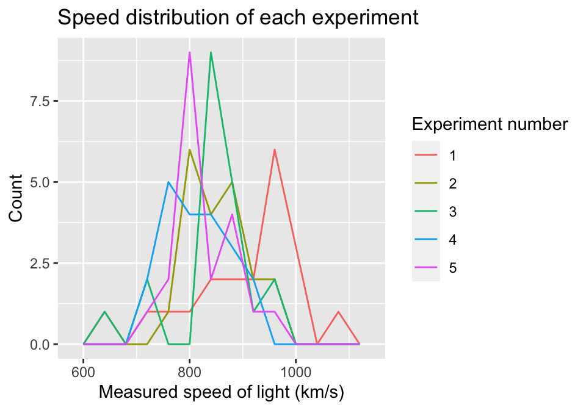

```r
  ggplot(morley, aes(Speed, colour = Expt)) +
  geom_freqpoly(binwidth = 40) +
  labs(
    title = "Speed distribution of each experiment",
    x = "Measured speed of light (km/s)",
    y = "Count",
    colour = "Experiment number"
  )
```

10. What is the advantage of using non-faceted frequency polygons compared to faceted histograms? What is the disadvantage?
- The advantage of using frequency polygons instead of faceted histograms is that it saves space. Physically, the plot takes one set of axis and lables, and represents the information of different subgroups close to each other for ease of comparison.
- The disadvantage of using frequency polygons is readability. With the number of lines exceeding 3 or 4, is becomes increasingly difficult to ‘follow’ along each separate line as their slopes change. Plotting the lines on top of each other is also an area of concern which makes the plot less readable.